# hw2

## 讀取資料

```r
data1 <- read.csv("C:/Users/Lenovo/Desktop/titanic.csv", header=T)
head(data1)
```

```
##                                  name gender age class fare group
## 1        ALLEN, Miss Elisabeth Walton      1  29     1  211
## 2 ALLISON, Mr Hudson Joshua Creighton      0  30     1  151
## 3           ALLISON, Mrs Bessie Waldo      1  25     1  151
## 4         ALLISON, Miss Helen Loraine      1   2     1  151
## 5       ALLISON, Master Hudson Trevor      0   1     1  151
## 6                  ANDERSON, Mr Harry      0  47     1   26
##        joined         job boat survival
## 1 Southampton                2        1
## 2 Southampton Businessman             0
## 3 Southampton                         0
## 4 Southampton                         0
## 5 Southampton               11        1
## 6 Southampton Stockbroker    3        1
```

## 整理資料

將乘客及員工分開之資料分開，並將資料中為9999的值視為遺失值而剃除

```r
cus <- data1[data1$class %in% c(1,2,3),]
boa <- data1[!data1$class %in% c(1,2,3),]

cus <- cus[!cus$fare == 9999,]
cus <- cus[!cus$age == 9999,]
boa <- boa[!boa$age == 9999,]
```

## 船員及乘客的基本敘述統計

由於原始資料沒有說明性別中0和1代表的性別，由船員的性別分布結果來看，我推論0為男性，1為女性

```r
#乘客年齡分布
summary(cus$age)
```

```
##    Min. 1st Qu.  Median    Mean 3rd Qu.    Max.
##    1.00   21.00   27.00   29.35   37.00   74.00
```

```r
#船員年齡分布
summary(boa$age)
```

```
##    Min. 1st Qu.  Median    Mean 3rd Qu.    Max.
##   14.00   24.00   30.00   30.65   36.00   62.00
```

```r
#乘客性別分布
table(cus$gender)
```

```
##
##   0   1
## 826 459
```

```r
#船員性別分布
table(boa$gender)
```

```
##
##   0   1
## 864  23
```

## 問題ㄧ 是否獨自乘船的死亡率

此處僅使用乘客資料，要探討的問題為「是否以單獨身分在船上」的乘客死亡率。

使用的方式為將姓名字串以逗號分隔後，將同樣姓氏的人設為ㄧ家人，並創造一個新變數後，1表示單獨在船上，0則表示船上有家人。

此方法或許嚴謹性不足因只要同姓氏就會被算成ㄧ家人，若有更齊全的船員背景資料則能做更嚴謹的分析，但這裡做出的結果事有差異的：有家庭在船上的死亡率低於單獨在船上的，估計是因為家庭會幫助自己家中的老弱婦孺先行上船，單身的人則也較是在災難時幫助別人上船的。

```r
nam <- strsplit(as.character(cus$name),",",fixed = T)
a1 <- unlist(nam)
a2 <- a1[seq(1,length(a1)-2,2)]
fam <- names(table(a2)[table(a2)>1])
cus$lastname <- a2
cus$singal <- rep(1,1285)
cus$singal[cus$lastname %in% fam] = 0
af <- table(cus$survival,cus$singal)
#家庭搭船死亡率
af[1,1] / (af[1,1]+af[2,1])
```

```
## [1] 0.5770548
```

```r
#單獨搭船死亡率
af[1,2] / (af[1,2]+af[2,2])
```

```
## [1] 0.6590585
```

## 問題二 高消費者的上救生艇率

由summary函數得到票價的第三四分位距為31元，故把大於31元的票價定義為高消費族群後，再與是否上救生艇做出列聯表，從結果可以發現票價高能上救生艇的比率顯著的較ㄧ般的乘客來的高，直接拿是否為高價位票價乘客的死亡率做比較後，更能得出票價高有較高存活率的結論。

```r
library(dplyr)
rich <- select(cus,fare,boat,survival) %>%
  filter(fare > summary(cus$fare)[5])
table(rich$boat)
```

```
##
##       1  10  11  12  13  14  15  16   2   3   4   5   6   7   8   9   A
## 123   4  12  11   0   3  12   0   0   6  21  23  22  16  13  20   7   3
##   B   C   D
##   1   5   8
```

```r
#票價貴的上救生艇率
a1 <- sum(table(rich$boat)[-1]) / sum(table(rich$boat))
#不分票價乘客的上救生艇率
a2 <- sum(table(cus$boat)[-1]) / sum(table(cus$boat))
aa <- as.data.frame(cbind(a1,a2))
names(aa) <- c('票價貴的上救生艇率','不分票價乘客的上救生艇率')
print(aa)
```

```
##   票價貴的上救生艇率 不分票價乘客的上救生艇率
## 1          0.6032258                0.3782101
```

```r
#票價貴的死亡率
a3 <- table(rich$survival)[1] / sum(table(rich$survival))
#不分票價的死亡率
a4 <- table(cus$survival)[1] / sum(table(cus$survival))
aa2 <- as.data.frame(cbind(a3,a4))
names(aa2) <- c('票價貴的死亡率','不分票價的死亡率')
print(aa2)
```

```
##   票價貴的死亡率 不分票價的死亡率
## 0      0.3967742        0.6217899
```

## 問題三 老弱婦孺的死亡率

從資料的年齡分布來看，我取小於20歲及大於50歲做為小孩及老人的年齡，在比較死亡率後，可以看出老人及小孩的死亡率是顯著低於所有人的比例的。

接著因為是想查看老弱婦孺，因此把性別也納入考量，真正的「老弱婦孺」跟所有人的死亡率做比較的話差異極大，但把女性的死亡率單獨抓出來才發現，女性的死亡率本來就偏低，因此把整個老弱婦孺的死亡率都拉低了。

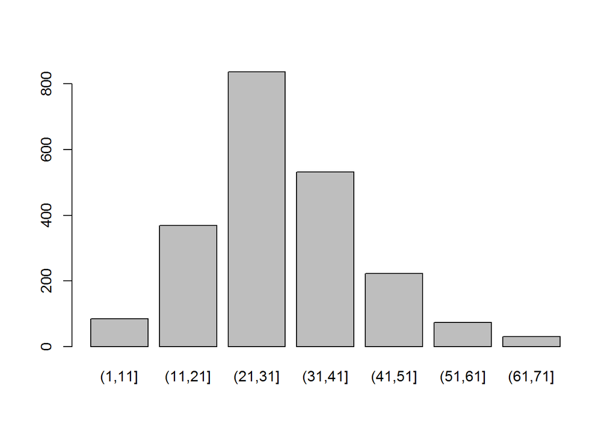

```r
cus <- data1[data1$class %in% c(1,2,3),]
boa <- data1[!data1$class %in% c(1,2,3),]
cus <- cus[!cus$fare == 9999,]
cus <- cus[!cus$age == 9999,]
boa <- boa[!boa$age == 9999,]
allb <- rbind(cus,boa)
barplot(table(cut(allb$age,seq(1,71,10))))
```

```r
weak <- select(allb,gender,age,survival) %>%
  filter(age > 50|age < 20)
table(weak$survival)
```

```
##
##   0   1
## 283 148
```

```r
#老少的死亡率
b1 <- table(weak$survival)[1] / sum(table(weak$survival))
#所有人的死亡率
b2 <- table(allb$survival)[1] / sum(table(allb$survival))
bb <- as.data.frame(cbind(b1,b2))
names(bb) <- c('老少的死亡率','所有人的死亡率')
print(bb)
```

```
##   老少的死亡率 所有人的死亡率
## 0    0.6566125       0.735267
```

```r
#老弱婦孺的死亡率
weakg <- select(allb,gender,age,survival) %>%
  filter(age > 50|age < 20 , gender==1)
b3 <- table(weakg$survival)[1] / sum(table(weakg$survival))
#所有女性死亡率
fem <- select(allb,gender,age,survival) %>%
  filter(gender==1)
b4 <- table(fem$survival)[1] / sum(table(fem$survival))
bb2 <- as.data.frame(cbind(b3,b4))
names(bb2) <- c('老弱婦孺的死亡率','所有女性的死亡率')
print(bb2)
```

```
##   老弱婦孺的死亡率 所有女性的死亡率
## 0        0.3377483        0.3381743
```